# Proyecto: Análisis de sensibilidad de del precio de productos agrícolas a factores externos

# 1 Introducción

En Colombia la producción agricola se enfrenta a retos complejos como el cambio climático, la interrupción de suministros y la competencia externa. Factores como la inflación, el aumento de precios de insumos, transporte, almacenamiento, fenómenos climáticos y malos negocios con intermediarios terminan afectando al productor. Por ejemplo, el diario Portafolio reporta que hace 18 meses producir una hectárea de papa costaba alrededor de $22 millones y los valores de hoy están cercanos a los $40 millones por hectárea. Además de esto los pequeños y medianos productores tienen que competir con importaciones de paises tecnificados donde la producción es más económica y eficiente.

Desde esta problemática consideramos que es fundamental conocer las tendencias del mercado y los factores que afectan a los cultivos. En el siguiente proyecto realizamos algunos análisis para ayudar a los productores a tomar desiciones informadas y que estas les permitan ser competitivos en el mercado.

# 2 Metodología

## 2.1 ¿Cómo abordaremos el problema?

Utilizaremos datos históricos de los precios de productos agrícolas en diferentes centros mayoristas del pais, nos centramos en los datos producidos por el departamento nacional de estadística, DANE. Elegimos la **región andina** de Colombia para acotar el problema, y también nos enfocamos en los productos cosechados en esta región. Analizaremos la variabilidad del precio a lo largo del tiempo con el objetivo de identificar los productos más estables, buscando identificar aquellos que podrían tener una rentabilidad más segura. Usaremos datos de algunos factores relacionado en la cadena de producción o suministro, como la inflación, los precios de diferentes insumos y los patrones de precios que siguen estos productos anualmente.

## 2.2 ¿Qué medidas estadísticas usaremos?

Para analizar los datos utilizaremos principalmente las medidas de tendencia central estadística como la media y la desviación estándar para medir la variabilidad de los productos a lo largo del tiempo. A su vez usaremos la correlación para buscar posibles relaciones entre los precios de los insumos, la tasa de inflación a nivel país y los precios de los productos desde 2013 hasta 2023.

## 2.3 Nuestro objetivo: Generar recomendaciones para la producción agrícola

El objetivo de nuestro proyecto es contribuir a la toma de decisiones informadas en la producción agrícola de pequeña o mediana escala, desde el análisis de datos reales de variables relacionadas al precio de los productos.

## 2.4 📚 Librerías y funciones usadas

A continuación un resumen de las librerías usadas y su propósito.

| Librería | Propósito |
| --- | --- |
| RColorBrewer | Generación de paletas de colores |
| readxl | Lectura de archivos Excel |
| ggplot2 | Creación de gráficos estadísticos |
| tidyverse | Conjunto de herramientas para el análisis de datos |
| cowplot | Combinación de gráficos |
| lubridate | Manejo de fechas y horas |
| patchwork | Combinación de gráficos |
| tidyr | Transformación de datos |
| dplyr | Selección, manipulación y agregación de datos |
| lubridate | Manejo de fechas y horas |
| skimr | Exploración de datos |
| kableExtra | Mejorar la apariencia de las tablas generadas por la función kable() de la librería knitr |
| knitr | Generar documentos reproducibles en R que contengan código R, texto, tablas y gráficos |
| DT | Crear tablas interactivas en R que pueden ser utilizadas para explorar datos de manera interactiva |

# 3 🗒 Datos

## 3.1 💾 Fuentes: obtener los datos

En nuestros análisis utilizamos conjuntos de datos de dos fuentes

1. DANE (2023) Sistema de Información de Precios y Abastecimiento del Sector Agropecuario (SIPSA). Gobierno de Colombia. Recuperado el 15 de Noviembre de 2023 de: https://www.dane.gov.co/index.php/estadisticas-por-tema/agropecuario/sistema-de-informacion-de-precios-sipsa#precios-mayoristas.
2. DANE (2023) Inflacion total y meta. Banco de la Republica. Recuperado el 15 de Noviembre de 2023 de: https://www.banrep.gov.co/es/estadisticas/inflacion-total-y-meta

## 3.2 Datos históricos de precios mayoristas

Datos recolectados por el DANE como parte de la operación SIPSA (Sistema de información de Precios y Abastecimiento) desde el 2012 hasta la fecha. Los conjuntos de datos disponbles son: Precios Mayoristas, Abastecimientos de Alimentos e Insumos y Factores Asociados a la Producción Agropecuaria. Estos datos se recolectan mediante entrevista personal con formulario de papel, en el siguiente enlace se encuentra la ficha técnica https://microdatos.dane.gov.co/index.php/catalog/776

Las series históricas de precios mayoristas tienen 5 variables, la fecha en la cual se tomó la medición del precio del producto, el grupo al que pertenece el producto, el producto como tal, el mercado en donde se tomó la medición y el precio promedio por kilogramo.

A continuación información sobre los datos.

```
## [1] "Número de campos NaN"
```

```
## [1] 1146
```

Características del dataset

|  | Fecha | Grupo | Producto | Ciudad | Mercado | Precio |
| --- | --- | --- | --- | --- | --- | --- |
|  | Min. :2013-01-01 00:00:00.00 | Length:603782 | Length:603782 | Length:603782 | Length:603782 | Min. : 82 |
|  | 1st Qu.:2015-09-01 00:00:00.00 | Class :character | Class :character | Class :character | Class :character | 1st Qu.: 1429 |
|  | Median :2018-05-01 00:00:00.00 | Mode :character | Mode :character | Mode :character | Mode :character | Median : 2990 |
|  | Mean :2018-05-04 08:25:59.39 | NA | NA | NA | NA | Mean : 6369 |
|  | 3rd Qu.:2021-01-01 00:00:00.00 | NA | NA | NA | NA | 3rd Qu.: 8500 |
|  | Max. :2023-10-01 00:00:00.00 | NA | NA | NA | NA | Max. :184278 |

Valores únicos por columna

|  | x |
| --- | --- |
| Fecha | 130 |
| Grupo | 9 |
| Producto | 383 |
| Ciudad | 70 |
| Mercado | 110 |
| Precio | 31304 |

|  | Fecha | Grupo | Producto | Ciudad | Mercado | Precio |
| --- | --- | --- | --- | --- | --- | --- |
| 1 | 2023-01-01T00:00:00Z | VERDURAS Y HORTALIZAS | Acelga | Armenia | Armenia, Mercar | 1706 |
| 2 | 2023-01-01T00:00:00Z | VERDURAS Y HORTALIZAS | Acelga | Bogotá | Bogotá, D.C., Corabastos | 906 |
| 3 | 2023-01-01T00:00:00Z | VERDURAS Y HORTALIZAS | Acelga | Bucaramanga | Bucaramanga, Centroabastos | 2000 |
| 4 | 2023-01-01T00:00:00Z | VERDURAS Y HORTALIZAS | Acelga | Chiquinquirá (Boyacá) | Chiquinquirá (Boyacá) | 1722 |
| 5 | 2023-01-01T00:00:00Z | VERDURAS Y HORTALIZAS | Acelga | Duitama (Boyacá) | Duitama (Boyacá), Mercaplaza | 1858 |
| 6 | 2023-01-01T00:00:00Z | VERDURAS Y HORTALIZAS | Acelga | Florencia (Caquetá) | Florencia (Caquetá) | 2733 |
| 7 | 2023-01-01T00:00:00Z | VERDURAS Y HORTALIZAS | Acelga | Ibagué | Ibagué, Plaza La 21 | 1840 |
| 8 | 2023-01-01T00:00:00Z | VERDURAS Y HORTALIZAS | Acelga | Ipiales (Nariño) | Ipiales (Nariño), Ipiales somos todos | 1808 |
| 9 | 2023-01-01T00:00:00Z | VERDURAS Y HORTALIZAS | Acelga | Medellín | Medellín, Central Mayorista de Antioquia | 1955 |
| 10 | 2023-01-01T00:00:00Z | VERDURAS Y HORTALIZAS | Acelga | Neiva | Neiva, Surabastos | 2403 |

[output cut: 990 more lines]

```
## [1] "Total filas  603782"
```

## 3.3 Datos históricos de insumos

Leemos los archivos y damos un primer vistazo a los datos.

| Año | Mes | Código departamento | Nombre departamento | Código municipio | Nombre municipio | Nombre del producto | Presentación del producto | Precio promedio |
| --- | --- | --- | --- | --- | --- | --- | --- | --- |
| 2013 | Enero | 11 | Bogotá, D.C. | 11001 | Bogotá, D.C. | 10-20-20 | 50 kilogramos | 83200 |
| 2013 | Enero | 68 | Santander | 68001 | Bucaramanga | 10-20-20 | 50 kilogramos | 75500 |
| 2013 | Enero | 73 | Tolima | 73124 | Cajamarca | 10-20-20 | 50 kilogramos | 85480 |
| 2013 | Enero | 76 | Valle del Cauca | 76001 | Cali | 10-20-20 | 50 kilogramos | 93100 |
| 2013 | Enero | 25 | Cundinamarca | 25151 | Cáqueza | 10-20-20 | 50 kilogramos | 84000 |
| 2013 | Enero | 25 | Cundinamarca | 25178 | Chipaque | 10-20-20 | 50 kilogramos | 80000 |

| Año | Mes | Código departamento | Nombre departamento | Código municipio | Nombre municipio | Nombre del producto | Presentación del producto | Precio promedio |
| --- | --- | --- | --- | --- | --- | --- | --- | --- |
| 2023 | Octubre | 73 | Tolima | 73168 | Chaparral | Wuxal Tapa Roja | 1 litro | 49600.0 |
| 2023 | Octubre | 86 | Putumayo | 86749 | Sibundoy | Wuxal Tapa Roja | 1 litro | 50850.0 |
| 2023 | Octubre | 73 | Tolima | 73671 | Saldaña | Zinboquim | 1 litro | 22700.0 |
| 2023 | Octubre | 73 | Tolima | 73671 | Saldaña | Zinboquim | 4 litros | 79725.0 |
| 2023 | Octubre | 17 | Caldas | 17174 | Chinchiná | Zincprod | 1 litro | 46862.5 |
| 2023 | Octubre | 05 | Antioquia | 05756 | Sonsón | Zintrac MgB | 1 litro | 75000.0 |

```
## [1] "Variables disponibles"
```

```
## [1] "Año"                       "Mes"
## [3] "Código departamento"       "Nombre departamento"
## [5] "Código municipio"          "Nombre municipio"
## [7] "Nombre del producto"       "Presentación del producto"
## [9] "Precio promedio"
```

Convertimos la fecha a una nueva columna en formato *YYYY-MM-DD*.

Número de NaN:

```
## [1] 0
```

Algunos parámetros estadísticos.

```
##    Min. 1st Qu.  Median    Mean 3rd Qu.    Max.
##    2867   16667   37000   57468   80175  460000
```

Productos presentes en el dataset:

Insumos reportados

10-20-20, 10-30-10, 13-26-6, 14-4-23-4, 15-15-15, 17-6-18-2(Mg), 18-18-18-1(Mg), 25-4-24, 28-4-0-6(S), Agrimins 8-5-0-6, Biocel Foliar, Boroliq Sl, Borozinco Foliar, Cal Agrícola, Cal Dolomita, Cerostress, Cloruro de Potasio 0-0-60, Cosmocel: 20-30-10 + Edta y Em, Crecer 500, Desarrollo: 30-7-6, Florescencia: 10-28-19, Formador 2000, Fosfato Diamónico (DAP) 18-46-0, Fosfostress, Frutoka: 3-0-40, Germi-K, Humita 15, Hydran Nova 19-4-19-3, Kelatex Calcio, Kelatex Magnesio, Kelatex Zinc, Klip - K Calcio-Boro, Klip Boro, Llenado de Grano 8-0-10 + Boro y Cobre, Nitromag 21-0-0-7, Nutrifoliar Completo, Nutrimins, 18-18-18, Omex Bio 8, Omex K-41, Potreros: 31-8-8-2, Rafos 12-24-12-2, Sulfato de Amonio (Sam) 21-0-0-24(S), Terra Sorb - Foliar, Todo en uno, Tottal, Urea 46%, Wuxal Calcio, Wuxal Tapa Negra, Wuxal Tapa Roja, Agrodesarrollo 25-3-5, Agrofast, Aminoset, Borozinco 240 Gr, Foscrop Pk: 0-30-20, Globafol, Raizal 400: 9-45-11, Sulcamag, Terra Sorb 4 - Radicular, Nutri 15, 10-20-30, 13-26-6-3(CaO) + menores con lombricompost, 25-15-0, A-Micsur, Aminoplant, B-Timin Ag: 25-4-25, Cal Dolomita 65-33, Cal Dolomita 70-25, Compuesto Abimgra, Foliagro 8-23-8 + Secundarios y Em, Hojas, Fertilizante Orgánico de Lombriz San Rafael, Kafe Caldas 25-3-19-3, M@Sai, Microcoljap NPK, Poliquel Multi, Triple Q, Triplehoja, 15-4-23-4(Mg), Amino K-3, Isabion, Marax, Dolfos, Cal Dolomita 57-35, Fosfato Diamónico (DAP) 21-53-0, Poliquel Calcio, Abono Orgánico, 10-30-10 + Secundarios, Fertigro 8-24-0, Todo en Uno, 17-6-18-6(Mg), 25-15-0-2(Mg), Biozyme Tf, Powerplex, Nitron Doble N Granulado: 26-0-0, 10-20-30-1, Agro-K: 0-39-52, Foss 61 Cristales, Kadostim, Microessentials Sz: 12-40-0-10(S), Zinboquim, Cal dolomita 70-25, Cal dolomita, Cosmo-R: 14-8-19 + Edta Y Em, Fertilimor, K-Fol: 0-20-50 Cristales, Cal dolomita 57-35, Unoagro 41-3-3, Nitrabor (Nitrato De Ca+B): 15-0-0-26, Hidran: 19-4-19-3, Sulfato de Potasio 0-0-50-18(S), Calfos Granulado, Nitromag, Nutrifos Agrofert-K, Cal dolomita 65-33, Solu@Gro: 40-3-3, Amida S (Urea-Sulfato De Amonio), Agrimins Completo, Agrimins Inicio, Nutrisuelo, 13-26-10-3(Mg), 27-11-11-2(Mg), Abonissa Kikes Cauca, Afek I, Afek Ii, Aminofer, Aminoquim, Ana-Bor, Arroz Fase 3: 24-0-17-5-6, Boro 21, Boro-K, Calfomag, Cosmo-Foliar Crecimiento: 18-28-8 + Edta Y Em, Cosmo-Foliar Llenado: 0-32-43 + Edta Y Em, Desarrollo: 28-7-12, Dol, Engru-S, Fertigro Calcio, Fertinvesa CaB, Fertinvesa Fosfito de Potasio, Fertinvesa K, Fertinvesa P, Fertirriego Solunk-P Clean: 13-3-43 Cristales, Flores y Frutos: 5-10-43 + Em, Fosfato de Potasio 0-40-53, Humiforte N-6, Integrador, Microfoliar Npk, Micronfos: 8-5-0 + Secundarios Y Em, Microrriego Inicio: 15-25-10, Nadir Fos, Nitro Xtend +S 40-0-0-6, Novaplant Ca-B, Novaplant Ca-B-Zn, Nutri-Aminox, Orbiagro, Pastos 5, Poliquel Zinc, Potak 41, Primer Estado: 15-17-15-2(Mgo), Producir Exa 600, Raise-1, R-Llenito, Solucat 10-52-10, Tercer Estado: 24-0-12-3 (Mgo), Treinta y 1 Grado 31-8-8-2+33% (S), Triple Quin- C, Vicor 3, Zincprod, 15-15-15-3 + Em, Fertinvesa N, Inicio: 13-36-12 + Em, Microrriego Producción: 10-3-40, Novaplant Fosforo, 12-24-12, Fosfacel 800: 20-53-0, Microrriego Menores, Soil, Tacol, Jocker Hj & H, Agrofercol efe-agro, Sulfato de Cobre Cristales, Nutri Phite P Foliar, Dkp 500, Cosmoquel Edta-Calcio, Microrriego Ca Mg: 14-0-3-15(Cao)-5(Mgo) Cristales, Azufre 720 Sc, Promotor 40-3-3, Cab, Sembramon 12-20-12-3 (MgO), 15-15-15 + Esm, Grado palmero 13-5-27-5, Rafos 12-24-12-2 (MgO) 1 S, 10-20-20-4, 10-30-10-3, 11-30-11, 12-24-24, 18-18-18 + Esm, 18-18-18-1-2, Abonagro 15-15-15-4, Afek II, Agrimins K Calcio Boro, Amida S (Urea-Sulfato de Amonio), Biozyme TF, CaB, Cosechando, Cosmo-Foliar Crecimiento: 18-28-8 + Edta y Em, Cosmo-Foliar Llenado: 0-32-43 + Edta y Em, Cosmo-R: 14-8-19 + Edta y Em, Desarrollo Sn Cristales, DKP 500, Fertinvesa, Fertiplant, Fertiplant-Mins, Foscrop PK: 0-30-20, Jocker H J & H, Klip - K Calcio, Levante, Mezclas Nórdicas Soluban 13-2-30-2, Microessentials SZ: 12-40-0-10(S), Microfoliar NPK, Micronfos: 8-5-0 + Secundarios y Em, Microrriego Ca Mg: 14-0-3-15(CaO)-5(MgO) Cristales, Nitrabor (Nitrato de Ca+B): 15-0-0-26, Nitrate Balancer, Nitro-K: 13-3-43 Cristales, Platanero: 11-5-27-7-9, Primer Estado: 15-17-15-2(MgO), Prod 17: 17-6-18-2+(S), Rafos 12-24-12-2(MgO) 1S, Roca Fosfórica, Sembramon 12-20-12-3(MgO), Sulfato de Amonio (SAM) 21-0-0-24(S), Tercer Estado: 24-0-12-3(MgO), Treinta y 1: 31-8-8-2+3(S), Zintrac MgB, 12-8-24-3(MgO), Globafol NF, Korn-Kali + B, Mezclas Guayacan: 31-8-8, Nutricarga 19-4-18-3(MgO), 13-26-10, 15-5-30, Nitro Xtend + Mg 39-0-3 + 2(MgO) + 3s, Viva NF, 10-54-10, Microkel Boro, 15-15-15-11(S), Humito P200 Fertil, Poliquel Magnesio + Aa, 15-15-15-10, Actiplant, Amino Gib, Microkel Calcio Boro, Soluplant CaBoK, Soluplant K-Llenado, Soluplant Solufoliar, 12-11-18-3(MgO)-8S+EM, Crecimix: 38-6-3 + Secundarios y Em, NBX+Mo, Todo en Uno NF, K-Tionic, Teprosyn Np+Zn, 20-3-18-3(MgO), CaBtrac, Sikon Fert Cobre Zinc, 12-11-18-3(MgO)-8S+Em, Triple 15 ARAMA

Municipios de los que se tienen datos.

Municipio con reporte de datos para insumos

Bogotá, D.C., Bucaramanga, Cajamarca, Cali, Cáqueza, Chipaque, Choachí, Corinto, Cota, El Carmen de Viboral, El Santuario, Entrerríos, Fómeque, Girón, Guarne, La Ceja, Manizales, Marinilla, Medellín, Palmira, Pamplona, Pasto, Peñol, Popayán, Pupiales, Rionegro, San Vicente Ferrer, Subachoque, Tunja, Túquerres, Ventaquemada, Ábrego, Agustín Codazzi, Chiquinquirá, Ocaña, Piendamó, Villa de San Diego de Ubaté, Andes, Calarcá, Guadalajara de Buga, Ibagué, La Plata, Málaga, Montenegro, Neiva, Quimbaya, Riosucio, San Gil, Santander de Quilichao, Tuluá, Vélez, Chocontá, Samacá, Sibaté, Villapinzón, Armenia, Caicedonia, Granada, Pereira, Santa Rosa de Cabal, Socorro, Barbosa, Belén de Umbría, Cúcuta, Duitama, Facatativá, Ipiales, Jamundí, La Dorada, La Pintada, La Unión, Madrid, Marsella, Moniquirá, Piedecuesta, San Alberto, San Pedro de Los Milagros, Santa Bárbara, Silos, Valledupar, Villanueva, Villavicencio, Yopal, Zipaquirá, Buesaco, Pitalito, El Zulia, Espinal, Puerto López, Lebrija, Garzón, Girardot, Chitagá, Aquitania, La Celia, Santa Rosa de Osos, Sogamoso, Cereté, Fresno, Sevilla, Tibaná, Magangué, Sabana de Torres, Apía, La Virginia, Roldanillo, Betania, Corozal, Pacho, Cartago, Chinácota, Aguachica, Fundación, Chinchiná, El Carmen de Bolívar, Anserma, Cartagena de Indias, Montería, San Vicente de Chucurí, Santa Marta, Cachipay, Chía, Neira, Funza, Saldaña, Viterbo, Puerto Tejada, Sincelejo, La Mesa, Villeta, San Marcos, Sabanalarga, Lérida, Fusagasugá, Guaduas, Sonsón, Yarumal, Cimitarra, Dagua, Garagoa, Sibundoy, Caucasia, Ramiriquí, El Rosal, San Sebastián de Mariquita, Campoalegre, Algeciras, San Bernardo, Salamina, Florencia, El Doncello, Cumbal, San Andrés de Tumaco, Guachucal, Puerto Rico, Guateque, Lorica, Sutamarchán, Toca, Belén, Guática, Chaparral, Líbano, Supía, Córdoba, Pasca, Abejorral, María La Baja, Donmatías, Saravena, Arauca, Arcabuco, Isnos, Turmequé, Rovira, Barranquilla, Galeras, Urrao, Trujillo, Quinchía, Santuario, Aguazul, Paz de Ariporo, Venadillo, Piendamó - Tunía, San José de Cúcuta, Icononzo, Anzoátegui, Tauramena, Guamo

Cambiamos el nombre de las columnas para facilitar el trabajo y **filtramos los datos para los departamentos andinos.**

```r
departamentos_andinos <- c("Antioquia", "Boyacá", "Cundinamarca", "Norte de Santander", "Santander",
                           "Tolima", "Huila", "Caldas", "Quindío", "Risaralda", "Nariño")

# cambiando nombres de columnas a algo mas amigable
insumos$Departamento <- insumos$`Nombre departamento`
insumos <- insumos[, !names(insumos) %in% 'Nombre departamento']

insumos$Insumo <- insumos$`Nombre del producto`
insumos <- insumos[, !names(insumos) %in% 'Nombre del producto']


insumos_andino <- insumos %>%
  filter(Departamento %in% departamentos_andinos)
```

```
## [1] "Número de registros de insumos andinos"
```

```
## [1] 129415
```

## 3.4 Datos históricos de abastecimiento

Las series históricas de abastecimiento tienen 38 variables, la fecha en la cual se tomó la medición, el total de abastecimiento, la variación mensual del abastecimiento, la variación anual del abastecimiento, dos variables de empalme, y de la número 7 a la 38 son distintos mercados en donde se tiene el valor de abastecimiento.

Inicialmente pensamos en relacionar el precio de los productos con los datos de abastecimiento, sin embargo, al revisar los datos de abastecimeinto notamos que el valor era un dato global. Por esta razón decidimos abandonar los análisis. La exploración inicial la realizamos con el script `scripts/preciosvsBodegas.R`

## 3.5 Datos inflación

Obtuvimos los datos de la tasa de inflación a nivel nacional

```r
nombre_archivo <- "datosRaw/1.1.INF_Serie historica Meta de inflacion IQY.xlsx"
file = nombre_archivo
sheets <- excel_sheets(file)
datos_inflacion <- readxl::read_xlsx(file, skip=7,sheet = sheets[1])
names(datos_inflacion) <- c("Fecha", "inflacionTotal", "limiteSuperior", "MetadeInflacion","limiteInferior")

datos_inflacion <- datos_inflacion %>%
  mutate(Fecha = as.Date(sub("(\\d{4})(\\d{2})\\..*", "\\1-\\2-01", Fecha))) %>%
  select(-limiteSuperior) %>%
  select(-MetadeInflacion) %>%
  select(-limiteInferior)

datos_inflacion <-  datos_inflacion %>%
  filter(year(Fecha) >= 2013)


kable(head(datos_inflacion), format = "markdown", caption="Datos inflación")
```

Datos inflación

| Fecha | inflacionTotal |
| --- | --- |
| 2023-10-01 | 10.48 |
| 2023-09-01 | 10.99 |
| 2023-08-01 | 11.43 |
| 2023-07-01 | 11.78 |
| 2023-06-01 | 12.13 |
| 2023-05-01 | 12.36 |

## 3.6 🧹 Extracción y limpieza

En términos técnicos los datos se encuentran en hojas de cálculo formato Excel, separados por periodos en diferentes archivos y/o hojas de cálculo. Para usarlos y entenderlos de una manera más eficiente, creamos un archivo agrupado, el script usado se encuentra en el directorio `scripts`. Además de esto, fue necesario hacer conversiones en las variables de fechas para poder realizar los análisis, especialmente las gráficas y la busqueda de relaciones.

La exploración inicial la realizamos de manera visual, el tamaño de los archivos nos permitio visualizarlo y entre otras cosas identificar las hojas y rangos en los que se encontraban los datos de interés.

# 4 📊 Visualización: ¿Qué tenemos?

## 4.1 Agrupar datos

Ya que hemos eliminado los datos nulos y arreglado los datos podemos ver que tienen.

```r
print(names(datos))
```

```
## [1] "Fecha"    "Grupo"    "Producto" "Ciudad"   "Mercado"  "Precio"
```

Nos aseguramos de que **por cada año hay aproximadamente la misma cantidad de filas**. A excepción de 2023 ya que los datos solo están hasta Octubre.

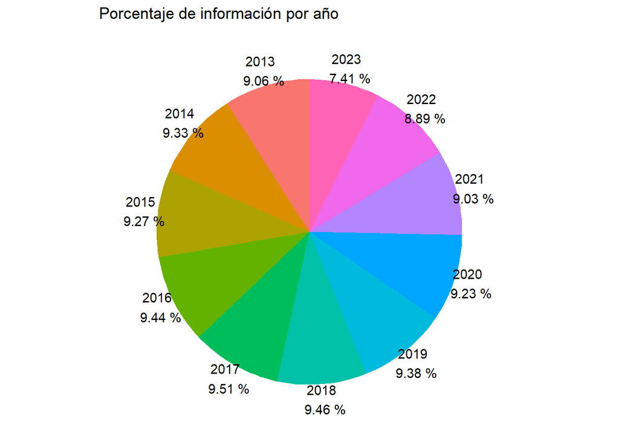

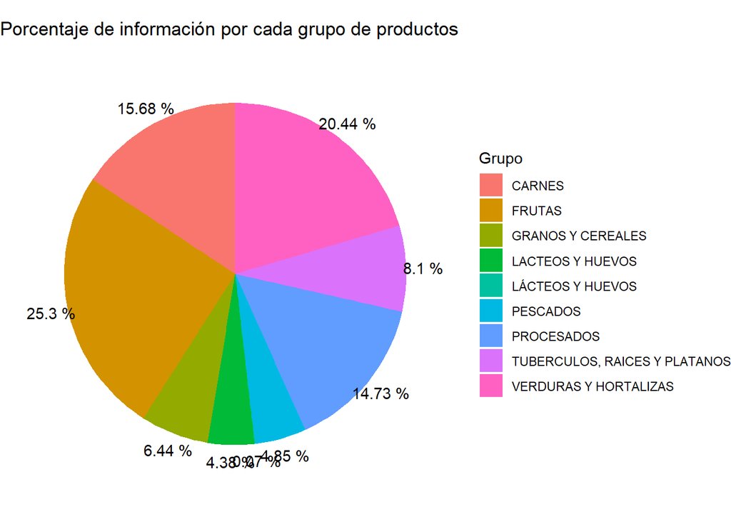

```
## [1] "Porcentaje productos agricolas 60.29"
```

En el grupo de productos agricolas **tenemos estos productos:**

| Grupo | Productos |
| --- | --- |
| FRUTAS | Aguacate común, Aguacate Hass, Aguacate papelillo, Badea, Banano bocadillo, Banano criollo, Banano Urabá, Borojó, Breva, Ciruela negra chilena, Ciruela roja, Coco, Curuba, Curuba redonda, Durazno impo… |
| GRANOS Y CEREALES | Arroz de primera, Arroz de segunda, Arroz excelso, Arroz sopa cristal, Arveja amarilla seca importada, Arveja enlatada, Arveja verde seca importada, Cuchuco de cebada, Cuchuco de maíz, Fríjol bolón, F… |
| TUBERCULOS, RAICES Y PLATANOS | Arracacha amarilla, Arracacha blanca, Ñame criollo, Ñame diamante, Ñame espino, Papa capira, Papa criolla limpia, Papa criolla para lavar, Papa criolla sucia, Papa ICA-Huila, Papa Morasurco, Papa neva… |
| VERDURAS Y HORTALIZAS | Acelga, Ahuyama, Ají topito dulce, Ajo, Ajo importado, Apio, Arveja verde en vaina, Arveja verde en vaina pastusa, Berenjena, Brócoli, Calabacín, Calabaza, Cebolla cabezona blanca, Cebolla cabezona bl… |

Además revisamos que tenemos muchas ciudades y mercados:

```r
print(paste("Ciudades : ", length(unique(datos$Ciudad))))
```

```
## [1] "Ciudades :  70"
```

## 4.2 ✂️Reducción del tamaño del dataset: Región andina

Ya que tenemos una gran cantidades de datos, **decidimos centrarnos en los principales productos de la región andina de Colombia**. Investigando en internet decidimos quedarnos con los **productos agricolas afines a esta región**. Entonces basaremos nuestro análisis en estos productos:

| Grupo | Productos |
| --- | --- |
| FRUTAS | Aguacate común, Aguacate Hass, Aguacate papelillo, Curuba, Curuba redonda, Feijoa, Fresa, Granadilla, Guanábana, Guayaba agria, Guayaba común, Guayaba manzana, Guayaba pera, Higo, Lulo, Mango común, M… |
| GRANOS Y CEREALES | Fríjol nima calima, Fríjol radical, Fríjol Uribe rosado |
| TUBERCULOS, RAICES Y PLATANOS | Arracacha amarilla, Arracacha blanca, Papa capira, Papa criolla limpia, Papa criolla sucia, Papa ICA-Huila, Papa nevada, Papa parda pastusa, Papa Puracé, Papa rubí, Papa R-12 negra, Papa R-12 roja, Pa… |

```
## [1] "Cantidad de productos:  58"
```

```
## [1] "Cantidad de mercados  38"
```

## 4.3 Comportamiento de los precios mayoristas en la región andina 2013-2023

Graficamos el comportamiento promedio de algunos productos buscando patrones anuales probablemente causados por el clima y la temporada en que se producen. En este caso observamos por ejemplo el aguacate papelillo, que es muy consumido en todo el país, la grafica muestra una tendecia muy clara a lo largo del año que se repite desde 2013 a 2023. El mínimo del precio coincide con la temporada de aguacates, cuando la oferta es mayor. También graficamos el comportamiento en diferentes ciudades para el año 2023 para ver si se trataba de un comportamiento a nivel nacional.

```r
p1 = producto_comportamiento_tiempo("Aguacate papelillo")
p2 = producto_comportamiento_ciudades("Aguacate papelillo", 2023)
```

[output not shown]

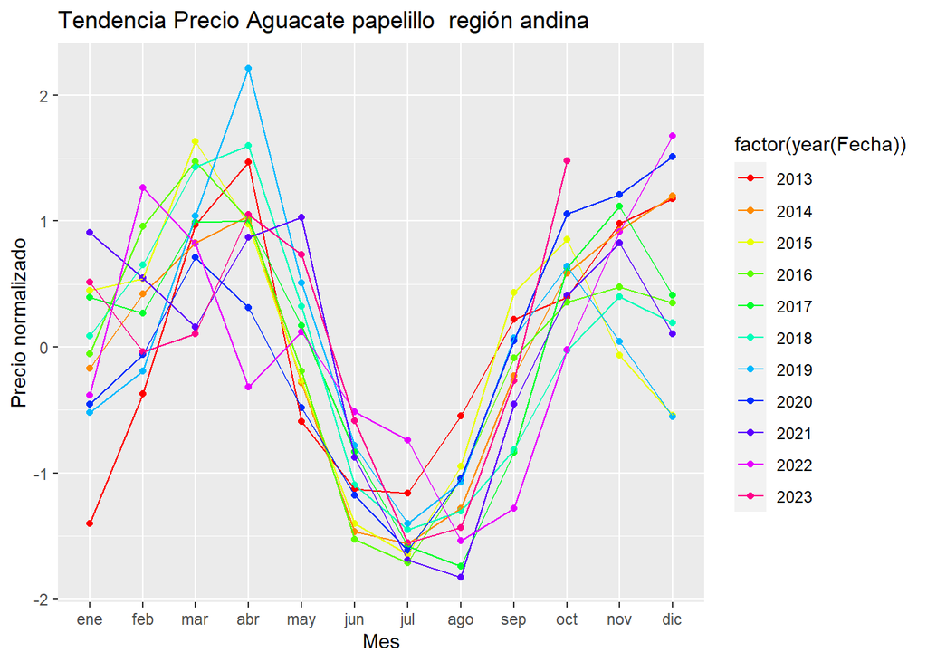

```r
print(p1)
```

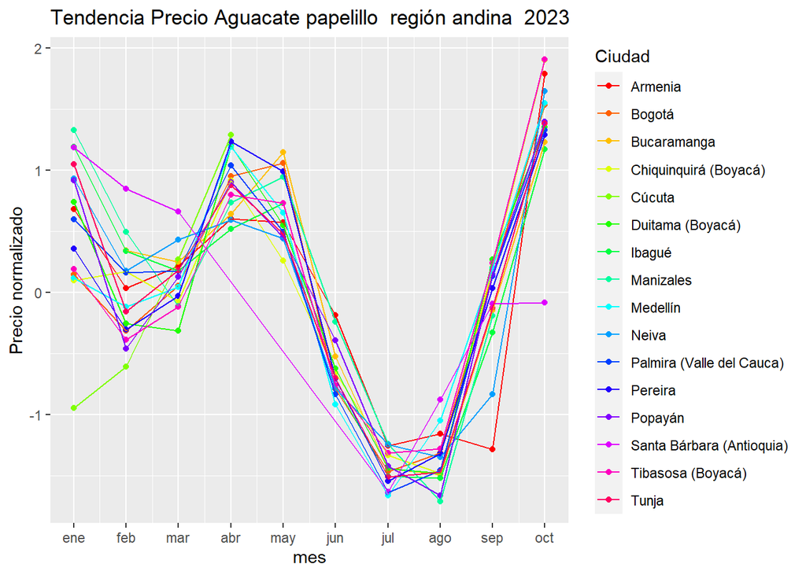

```r
print(p2)
```

## 4.4 Comportamiento de insumos 2013-2023

Variables disponibles

```r
names(insumos)
```

```
##  [1] "Año"                       "Mes"
##  [3] "Código departamento"       "Código municipio"
##  [5] "Nombre municipio"          "Presentación del producto"
##  [7] "Precio promedio"           "Fecha"
##  [9] "Departamento"              "Insumo"
```

Seleccionamos nitrogeno por ser este uno de los insumos más usado en los planes de fertilización y generamos algunos gráficos.

> Produto = Nitromag 21-0-0-7

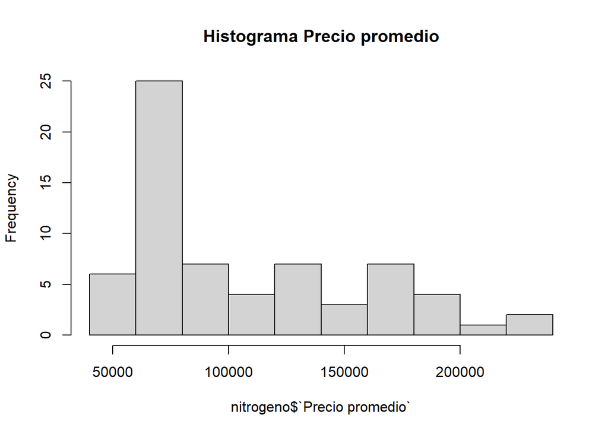

```r
nitrogeno <- filter(insumos, Insumo == "Nitromag 21-0-0-7" & `Nombre municipio` == "Socorro")

hist(nitrogeno$`Precio promedio`, main = "Histograma Precio promedio")
```

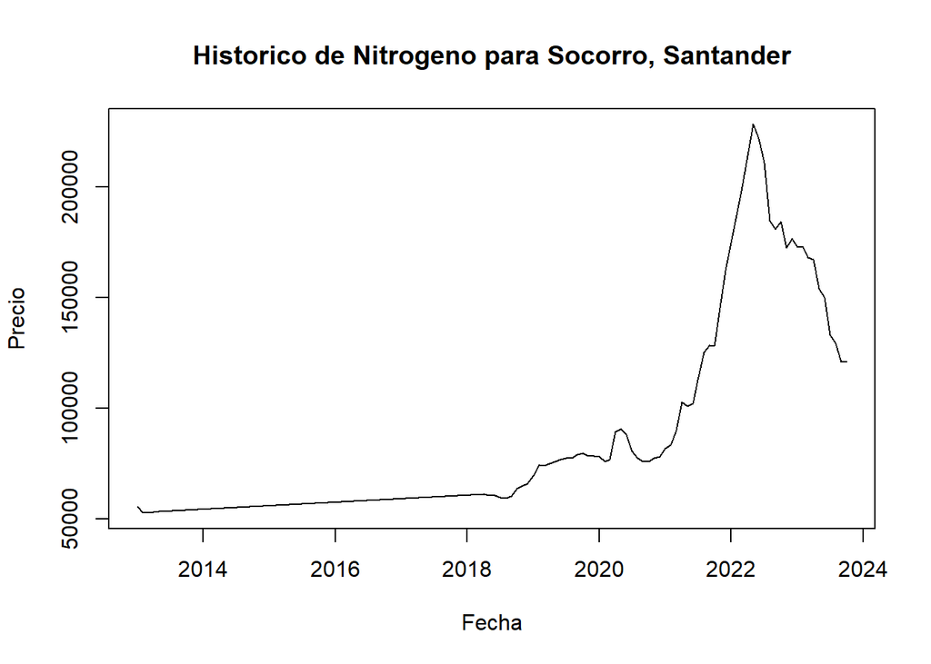

```r
# Historico
plot(nitrogeno$Fecha, nitrogeno$`Precio promedio`, type = "l", main = "Historico de Nitrogeno para Socorro, Santander", xlab = "Fecha", ylab = "Precio")
```

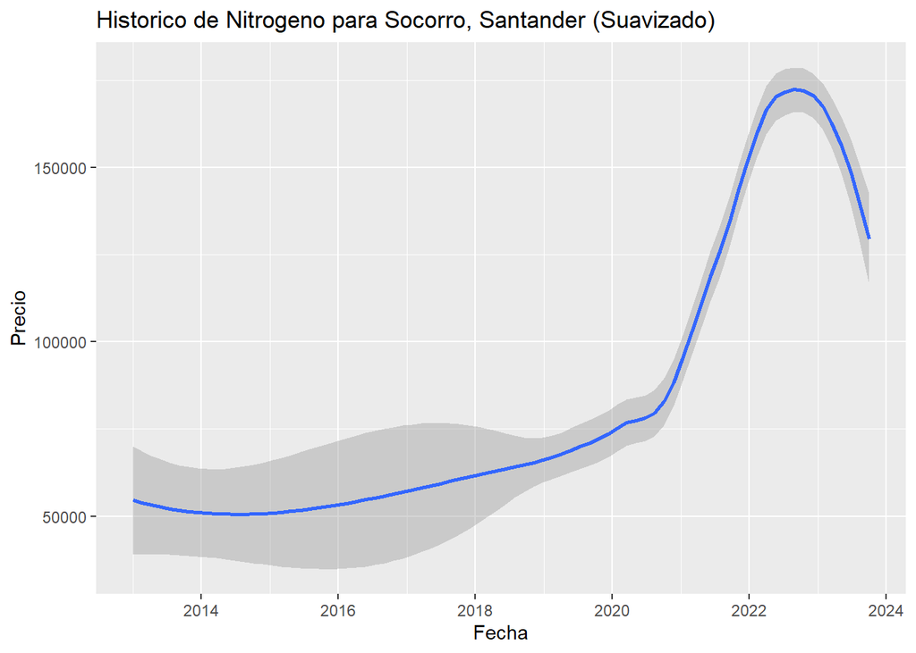

```r
# Historico suavizado
ggplot(nitrogeno, aes(x = Fecha, y = `Precio promedio`)) +
  geom_smooth(method = "loess", formula = y ~ x) +
  labs(title = "Historico de Nitrogeno para Socorro, Santander (Suavizado)", x = "Fecha", y = "Precio")
```

# 5 🔍 Análisis

## 5.1 📉 Filtrar productos por variabilidad

Ahora buscaremos los productos con menor y mayor variablidad en precio a lo largo del tiempo. Para esto **escribimos una función para normalizar los precios de un producto respecto al máximo precio de cada año.**

```r
# normalizar precios a nivel recional
normalizar_producto_tiempo <- function(nombre_producto){
  # Promedio mensual del precio a nivel regional
  promedios_regional <- datos_agro %>%
    filter(Producto == nombre_producto) %>%
    group_by(Fecha) %>%
    summarize(Promedio = mean(Precio))

  # Normalizar los precios para tener valores entre 0 y 1, mas faciles de comparar
  promedios_regional_normalizado <- promedios_regional %>%
    group_by(year = lubridate::year(Fecha)) %>%
    mutate(Promedio_normalizado = (Promedio / (max(Promedio, na.rm = TRUE))))

  return(promedios_regional_normalizado)
}
```

El código que se muestra anteriormente hace lo siguiente:

1. Por cada producto en el dataset se agrupa por fecha y se obtiene el promedio del precio por año-mes en toda la región andina.
2. Se normalizan los valores por año de cada producto. Los precios en 2013 serán más bajos que los de 2023 debido a la inflación. Como queremos ver la variabilidad del producto normalizaremos $precio\_normalizado = \frac{precio}{max(precio \ año)}$

Con los valores normalizados que retorna esa función podemos calcular la desviación estándar de los productos en el tiempo. Para verlo con un ejemplo con un par de productos:

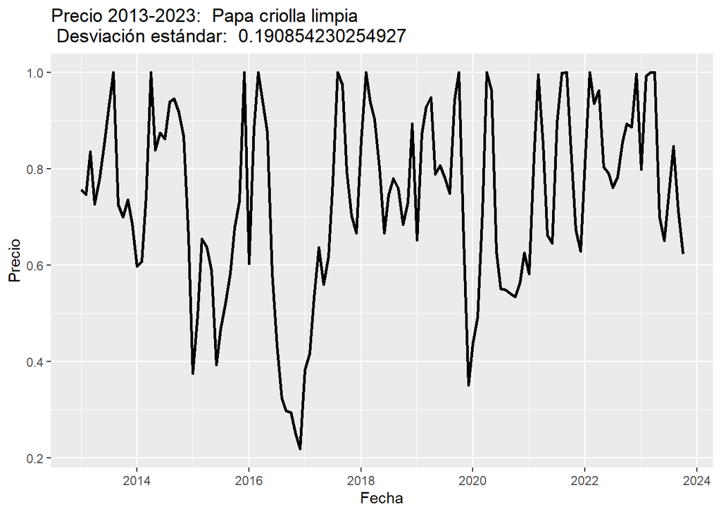

```r
i = "Papa criolla limpia"
promedios_regional_normalizado = normalizar_producto_tiempo(i)
sd = sd(promedios_regional_normalizado$Promedio_normalizado, na.rm = TRUE)
h <- ggplot() +
  geom_line(data = promedios_regional_normalizado, aes(x = Fecha, y = Promedio_normalizado), linewidth = 1) +
  labs(title = paste("Precio 2013-2023: ", i, "\n Desviación estándar: ", sd ),
       y="Precio")
print(h)
```

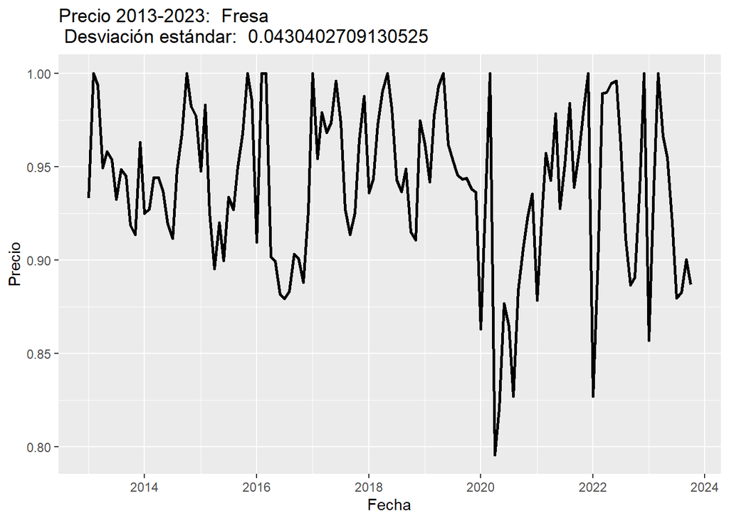

```r
# para un producto que casi no cambia
i = "Fresa"
promedios_regional_normalizado = normalizar_producto_tiempo(i)
sd = sd(promedios_regional_normalizado$Promedio_normalizado, na.rm = TRUE)
h <- ggplot() +
  geom_line(data = promedios_regional_normalizado, aes(x = Fecha, y = Promedio_normalizado), linewidth = 1) +
  labs(title = paste("Precio 2013-2023: ", i, "\n Desviación estándar: ", sd ),
       y="Precio")
print(h)
```

Obsevamos que la papa, que tiene una mayor desviación estándar presenta fluctuaciones en los precios de gran magnitud a lo largo de todo el tiempo de la muestra, mientras que la fresa que tiene una desviación estándar mucho menor fluctua a lo largo del año en mas o menos la misma magnitud, a excepción de a partir de 2020, lo que podría ser debido a la pandemia.

Ahora para todos los productos obtuvimos la desviación estándar, sin embargo notamos que habian varios productos que aparecen en muy pocas ciudades lo que nos da un resultado de baja confiabilidad.

```r
# Calcular desviacion estandar de los precios normalizados
df <- data.frame()

# Normalizar daticos agro por producto
for (i in unique(datos_agro$Producto)) {

  # Ver por año cuantas ciudades tienen ese producto en promedio
  numciudades <- promedioCiudades(i)

  # Obtener promedios regionales normalizados
  promedios_regional_normalizado = normalizar_producto_tiempo(i)

  # Calcular desviacion estandar de los precios normalizados
  r <- data.frame(
    Producto = i,
    Promedio_normalizado = mean(promedios_regional_normalizado$Promedio_normalizado, na.rm = TRUE),
    Sd = sd(promedios_regional_normalizado$Promedio_normalizado, na.rm = TRUE),
    Num_ciudades = numciudades
  )
  # Agregar fila al dataframe de resultado
  df <- bind_rows(df, r)
}
```

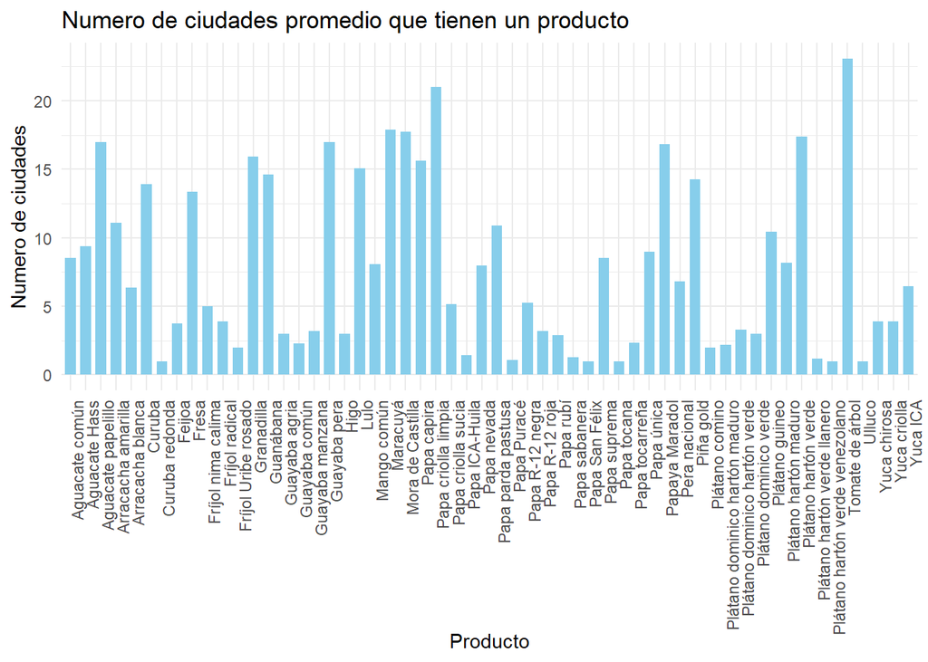

Filtrando los productos que aparezcan en promedio al menos en 10 ciudades, **buscamos los productos con menor y mayor desviacion estándar.**

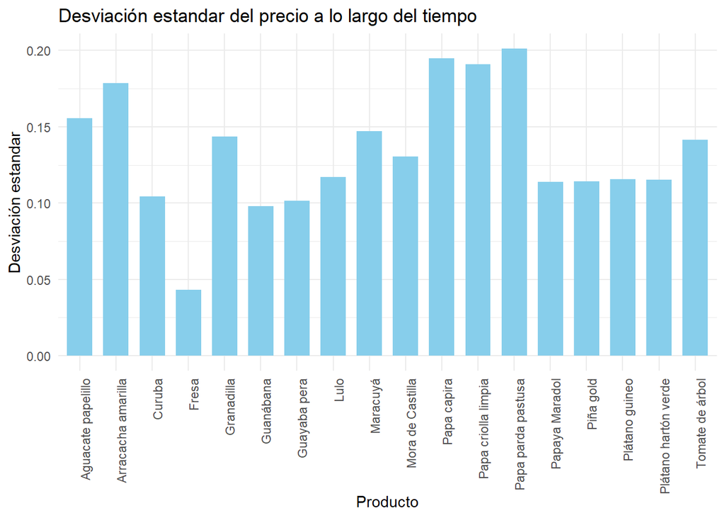

```r
df <- filter(df, Num_ciudades > 10 )
# Obtenemos n los datos que menos y mas varian
n = 3
menor_sd <- (arrange(df,Sd))
mayor_sd <- (arrange(df,desc(Sd)))

ggplot(df, aes(x = Producto, y = Sd )) +
  geom_bar(stat = "identity", fill = "skyblue", width = 0.7) +
  labs(
    title = "Desviación estandar del precio a lo largo del tiempo",
    x = "Producto",
    y = "Desviación estandar"
  ) +
  theme_minimal() +
  theme(axis.text.x = element_text(angle = 90, hjust = 1))
```

```r
kable(head(menor_sd, 5), format = "markdown",  caption = "Productos con menor desviación estándar")
```

Productos con menor desviación estándar

| Producto | Promedio_normalizado | Sd | Num_ciudades |
| --- | --- | --- | --- |
| Fresa | 0.9394952 | 0.0430403 | 13.36364 |
| Guanábana | 0.8669064 | 0.0980856 | 14.63636 |
| Guayaba pera | 0.8481332 | 0.1014958 | 17.00000 |
| Curuba | 0.8356012 | 0.1042286 | 13.90909 |
| Papaya Maradol | 0.8341735 | 0.1140267 | 16.81818 |

```r
selectos_min <- filter(datos_agro, Producto %in%  menor_sd[0:n,]$Producto)


kable(head(mayor_sd,5), format = "markdown", caption = "Productos con mayor desviación estándar")
```

Productos con mayor desviación estándar

| Producto | Promedio_normalizado | Sd | Num_ciudades |
| --- | --- | --- | --- |
| Papa parda pastusa | 0.6984575 | 0.2011734 | 10.90909 |
| Papa capira | 0.7266966 | 0.1949483 | 15.63636 |
| Papa criolla limpia | 0.7398807 | 0.1908542 | 21.00000 |
| Arracacha amarilla | 0.7988382 | 0.1786509 | 11.09091 |
| Aguacate papelillo | 0.7817468 | 0.1555544 | 17.00000 |

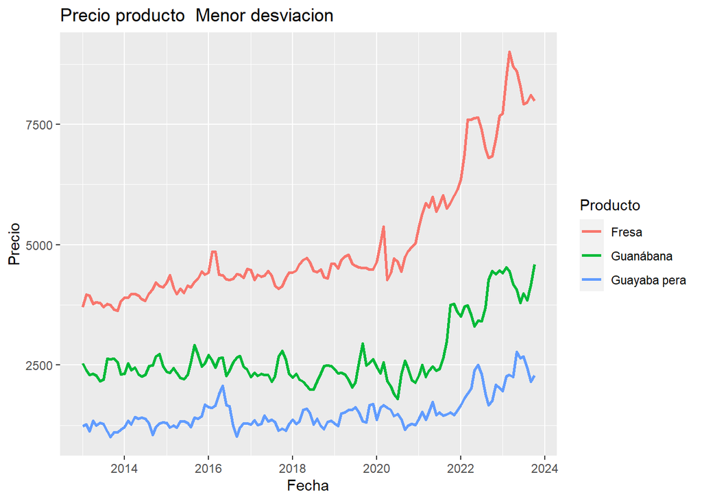

```r
selectos_max <- filter(datos_agro, Producto %in%  mayor_sd[0:n,]$Producto)


# Grafica la variacion del precio a lo largo del tiempo
plot_min <- graficar_tiempo_producto(selectos_min, "Menor desviacion")
plot_mas <- graficar_tiempo_producto(selectos_max, "Mayor desviacion")
# para graficar en una sola figura
print(plot_min)
```

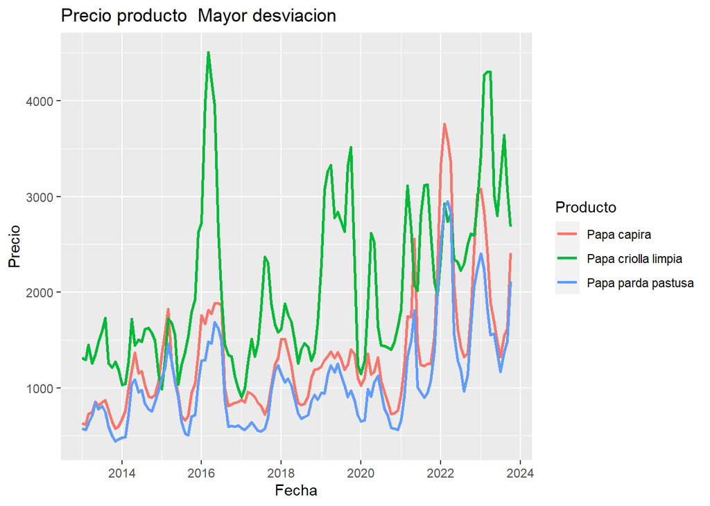

```r
print(plot_mas)
```

En los dos últmos gráficos observamos un comportamiento similar al ejemplo de la papa y la fresa que mencionamos anteriormente.

Ahora graficando los comportamientos anuales de cada producto. Estos resultados los analizaremos en la sección de discusión.

### 5.1.1 Productos con menor variabilidad

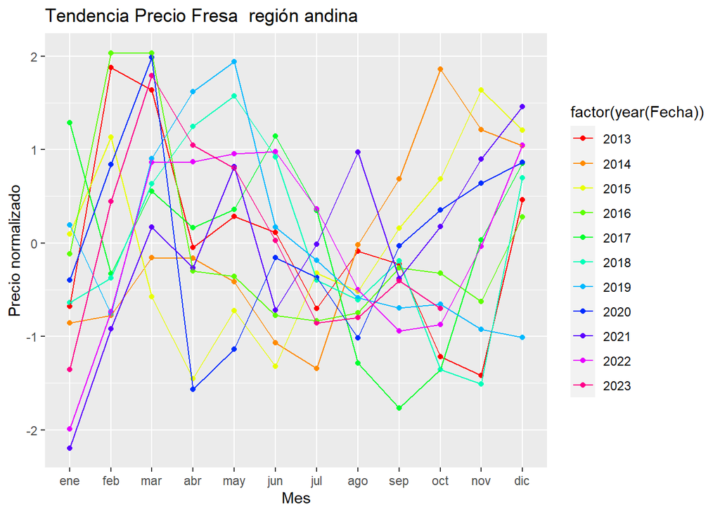

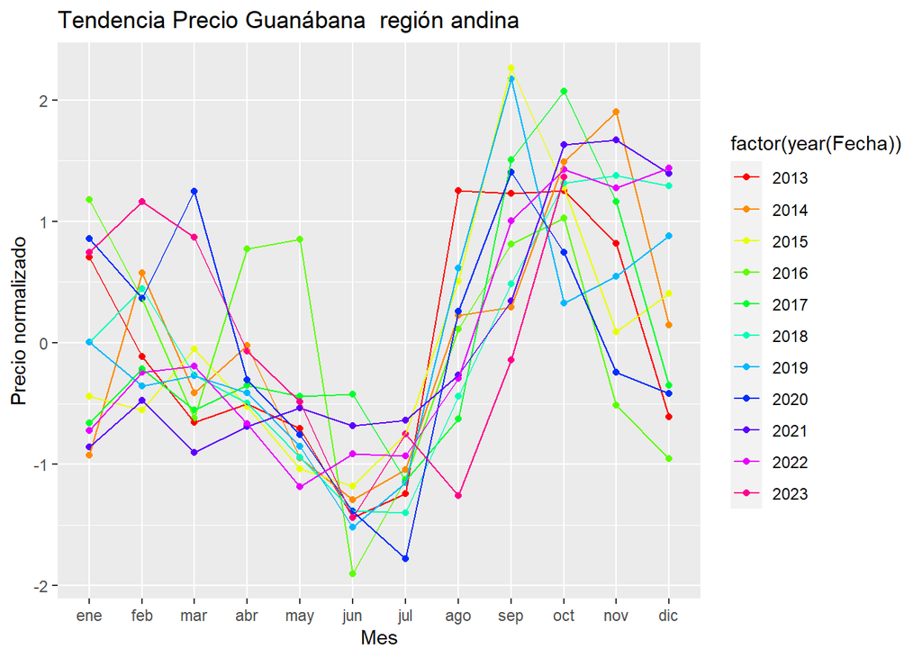

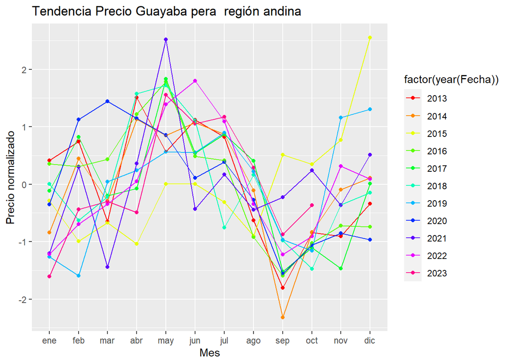

```r
# Graficar por cada producto
for(i in unique(selectos_min$Producto)) {
  plot1 <- producto_comportamiento_tiempo(i)
  print(plot1)
}
```

### 5.1.2 Productos con mayor variabilidad

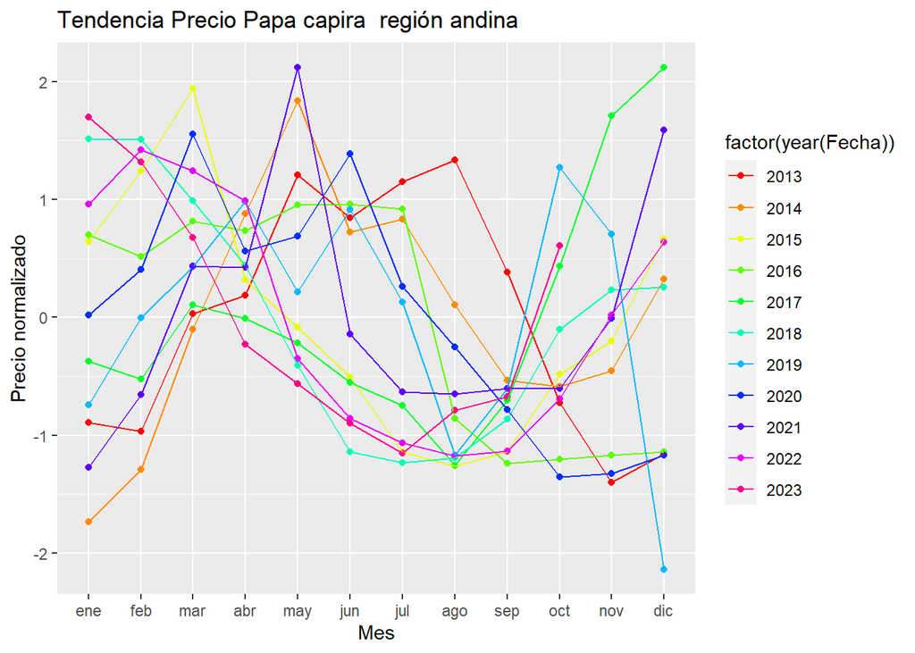

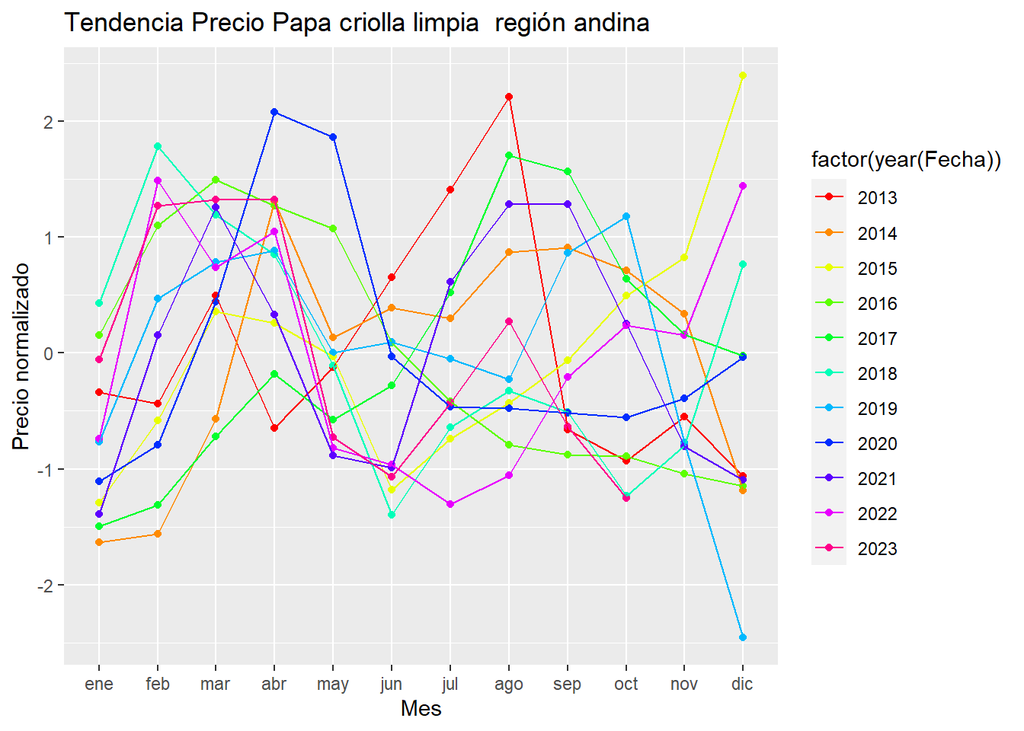

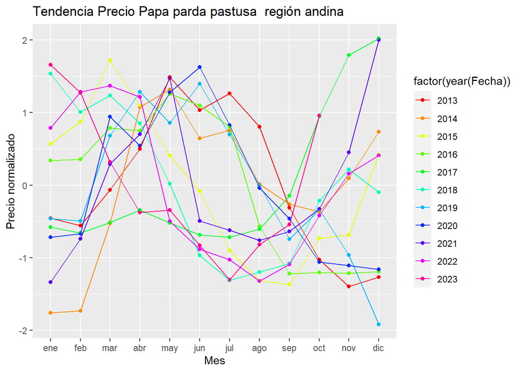

```r
# Graficar por cada producto
for(i in unique(selectos_max$Producto)) {
  plot1 <- producto_comportamiento_tiempo(i)
  print(plot1)
}
```

## 5.2 📈 Correlación con inflación

¿Qué tan afectados se ven los productos por la inflación a nivel nacional? Para responder esta pregunta:

1. Calculamos los promedios regionales de los productos para cada mes de 2013-2023
2. Obtenemos la correlación de cada producto con la tasa de inflación a nivel nacional por mes

```r
d <- rbind(selectos_min, selectos_max)

promedios_regional <- d %>%
  group_by(Fecha, Producto) %>%
  summarize(Promedio = mean(Precio))
promedios_regional$Fecha =format(promedios_regional$Fecha, "%Y-%m-%d")

merged_inflacion <- merge(promedios_regional, datos_inflacion, by = c("Fecha"))

correlation_matrix <- merged_inflacion %>%
  group_by(Producto) %>%
  summarise(correlation = cor(Promedio, inflacionTotal, use = "complete.obs"))

# Ordenar de mayor a menor
correlation_matrix <- correlation_matrix %>%
  arrange(desc(correlation))

kable(correlation_matrix, format = "markdown", caption="Correlación con tasa de inflación a nivel nacional")
```

Correlación con tasa de inflación a nivel nacional

| Producto | correlation |
| --- | --- |
| Guanábana | 0.8452602 |
| Guayaba pera | 0.7999897 |
| Fresa | 0.7951815 |
| Papa parda pastusa | 0.6357090 |
| Papa capira | 0.6249867 |
| Papa criolla limpia | 0.5825764 |

## 5.3 🖇️Correlación con fertilizantes

### 5.3.1 Nitrogeno:

Seleccionamos 3 productos para ver su comportamiento respecto al precio del Nitrogeno.

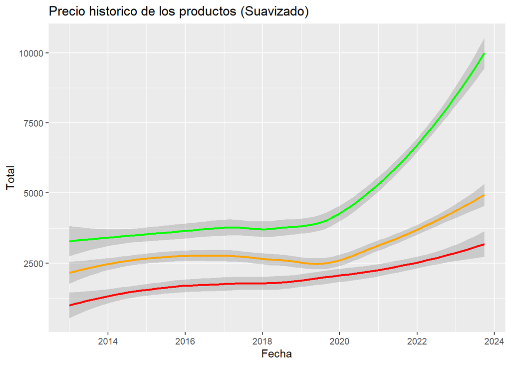

```r
producto <- filter(datos, Ciudad == "Bucaramanga" & Mercado == "Bucaramanga, Centroabastos" & Producto == "Lulo")
producto2 <- filter(datos, Ciudad == "Bucaramanga" & Mercado == "Bucaramanga, Centroabastos" & Producto == "Fresa")
producto3 <- filter(datos, Ciudad == "Bucaramanga" & Mercado == "Bucaramanga, Centroabastos" & Producto == "Papa criolla limpia")


ggplot(producto, aes(x = Fecha, y = Precio)) +
  geom_smooth(method = "loess", formula = y ~ x, color = "orange", label = "Lulo") +
  geom_smooth(data = producto2, aes(x = Fecha, y = Precio), color = "green", label = "Fresa") +
  geom_smooth(data = producto3, aes(x = Fecha, y = Precio), color = "red", label = "Papa criolla") +
  labs(title = "Precio historico de los productos (Suavizado)", x = "Fecha", y = "Total")
```

Normalizamos los valores para graficar los productos y el precio del insumo.

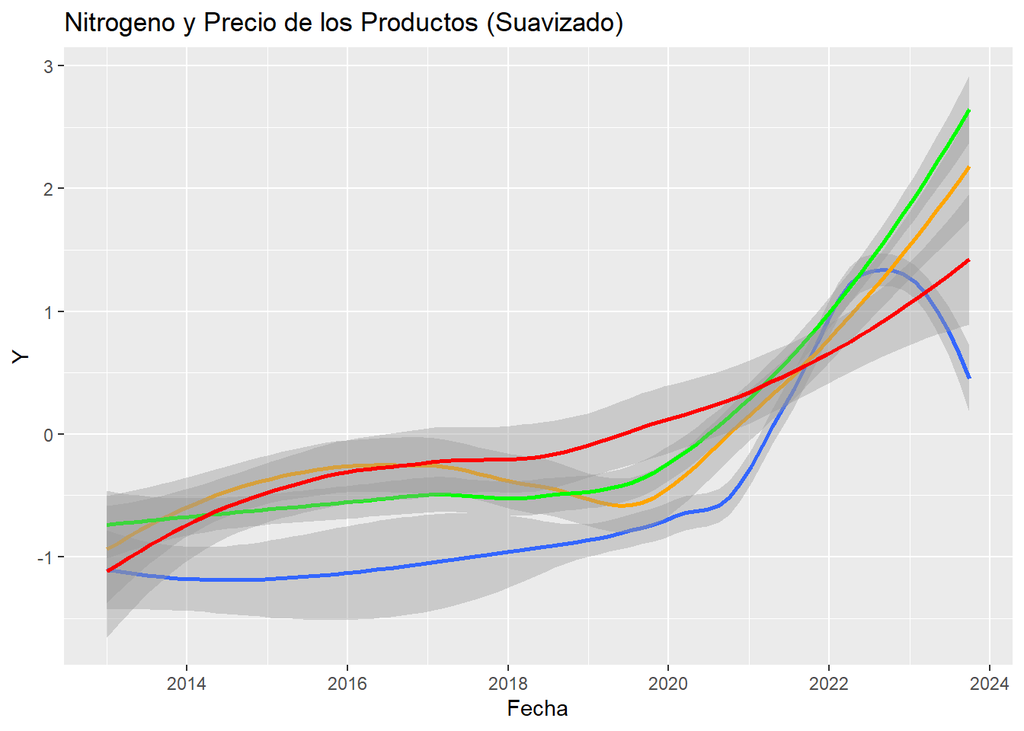

```r
productoNorm <- producto %>%
  mutate(precio_normalizado = scale(Precio))
producto2Norm <- producto2 %>%
  mutate(precio_normalizado = scale(Precio))
producto3Norm <- producto3 %>%
  mutate(precio_normalizado = scale(Precio))
insumosNorm <- nitrogeno %>%
  mutate(total_normalizado = scale(`Precio promedio`))

productoNorm$Fecha <- as.Date(productoNorm$Fecha, format = "%Y-%m-%d")
producto2Norm$Fecha <- as.Date(producto2Norm$Fecha, format = "%Y-%m-%d")
producto3Norm$Fecha <- as.Date(producto3Norm$Fecha, format = "%Y-%m-%d")


ggplot(insumosNorm, aes(x = Fecha, y = total_normalizado)) +
  geom_smooth(method = "loess", formula = y ~ x) +
  geom_smooth(data = productoNorm, aes(x = Fecha, y = precio_normalizado, label = "Lulo"), color = "orange", label = "Lulo") +
  geom_smooth(data = producto2Norm, aes(x = Fecha, y = precio_normalizado, label = "Fresa"), color = "green") +
  geom_smooth(data = producto3Norm, aes(x = Fecha, y = precio_normalizado, label = "Papa criolla"), color = "red") +
  labs(title = "Nitrogeno y Precio de los Productos (Suavizado)", x = "Fecha", y = "Y")
```

### 5.3.2 Correlación con otros insumos

Buscamos si existe una correlacion entre el precio de los productos y los insumos

1. Merge de ambos datasets para solo tener los datos en comun

```r
# Ver si existe una correlacion entre el precio de los productos y los insumos
# Paso 1: Merge de ambos datasets para solo tener los datos en comun
d <- rbind(selectos_min, selectos_max)

insumos_andino
```

| Año | Mes | Código departamento | Código municipio | Nombre municipio | Presentación del producto | Precio promedio | Fecha | Departamento | Insumo |
| --- | --- | --- | --- | --- | --- | --- | --- | --- | --- |
| 2013 | 1 | 68 | 68001 | Bucaramanga | 50 kilogramos | 75500.000 | 2013-01-01 | Santander | 10-20-20 |
| 2013 | 1 | 73 | 73124 | Cajamarca | 50 kilogramos | 85480.000 | 2013-01-01 | Tolima | 10-20-20 |
| 2013 | 1 | 25 | 25151 | Cáqueza | 50 kilogramos | 84000.000 | 2013-01-01 | Cundinamarca | 10-20-20 |
| 2013 | 1 | 25 | 25178 | Chipaque | 50 kilogramos | 80000.000 | 2013-01-01 | Cundinamarca | 10-20-20 |
| 2013 | 1 | 25 | 25181 | Choachí | 50 kilogramos | 83000.000 | 2013-01-01 | Cundinamarca | 10-20-20 |
| 2013 | 1 | 25 | 25214 | Cota | 50 kilogramos | 80000.000 | 2013-01-01 | Cundinamarca | 10-20-20 |
| 2013 | 1 | 05 | 05148 | El Carmen de Viboral | 50 kilogramos | 81433.000 | 2013-01-01 | Antioquia | 10-20-20 |
| 2013 | 1 | 05 | 05697 | El Santuario | 50 kilogramos | 80000.000 | 2013-01-01 | Antioquia | 10-20-20 |
| 2013 | 1 | 05 | 05264 | Entrerríos | 50 kilogramos | 83750.000 | 2013-01-01 | Antioquia | 10-20-20 |
| 2013 | 1 | 25 | 25279 | Fómeque | 50 kilogramos | 83000.000 | 2013-01-01 | Cundinamarca | 10-20-20 |

[output cut: 9990 more lines]

```r
merged_data <- merge(d, insumos_andino_f, by = c("Departamento", "Fecha"))
```

2. Crear la matriz de correlacion y ordenar

```r
# Paso 2: crear la matriz de correlacion
correlation_matrix <- merged_data %>%
  group_by(Producto, Insumo) %>%
  summarise(correlation = cor(Precio, `Precio promedio`, use = "complete.obs"))
# Ordenar de mayor a menor
correlation_matrix <- correlation_matrix %>%
  arrange(Producto, desc(abs(correlation)))
```

3. Por producto buscamos las mayores correlaciones

```r
top_correlations <- correlation_matrix %>%
  group_by(Producto) %>%
  top_n(3, wt = abs(correlation)) %>%
  arrange(Producto, desc(abs(correlation)))

# Print the top correlations
kable(top_correlations, format = "markdown", caption="Correlación con insumos")
```

Correlación con insumos

| Producto | Insumo | correlation |
| --- | --- | --- |
| Fresa | Foss 61 Cristales | 0.9632640 |
| Fresa | Agro-K: 0-39-52 | 0.9161117 |
| Fresa | 10-30-10 + Secundarios | 0.8699337 |
| Guanábana | Foss 61 Cristales | 0.8658286 |
| Guanábana | Hidran: 19-4-19-3 | 0.8523479 |
| Guanábana | Cosmocel: 20-30-10 + Edta y Em | 0.8064005 |
| Guayaba pera | Foss 61 Cristales | 0.8885687 |
| Guayaba pera | Cosmo-R: 14-8-19 + Edta y Em | 0.8566239 |
| Guayaba pera | Nutrisuelo | 0.8538115 |
| Papa capira | Rafos 12-24-12-2 | 0.7524141 |
| Papa capira | 25-15-0 | 0.7012806 |
| Papa capira | Nitro Xtend +S 40-0-0-6 | 0.6911096 |
| Papa criolla limpia | Kelatex Zinc | 0.7900062 |
| Papa criolla limpia | Foss 61 Cristales | 0.6355151 |
| Papa criolla limpia | Nitromag 21-0-0-7 | 0.6140538 |
| Papa parda pastusa | 25-4-24 | 0.7480960 |
| Papa parda pastusa | Boroliq Sl | 0.6992600 |
| Papa parda pastusa | Urea 46% | 0.6830631 |

4. Graficando los fertilizantes con los productos

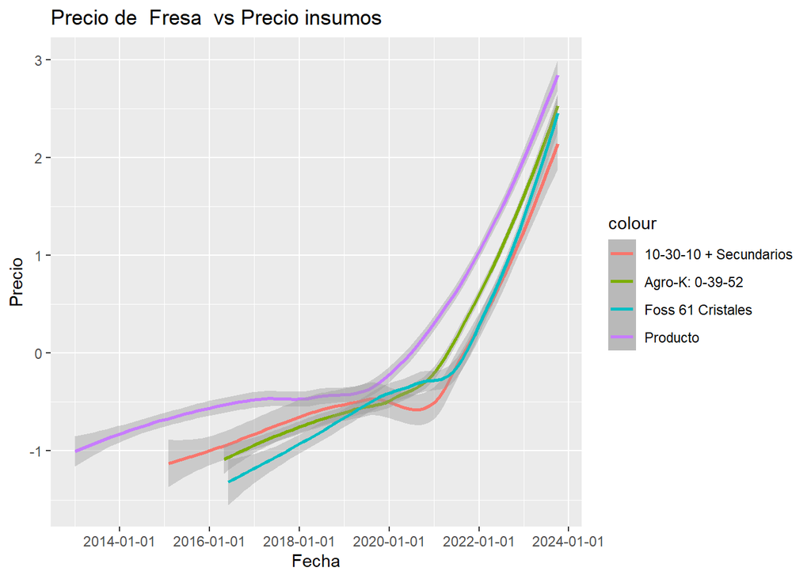

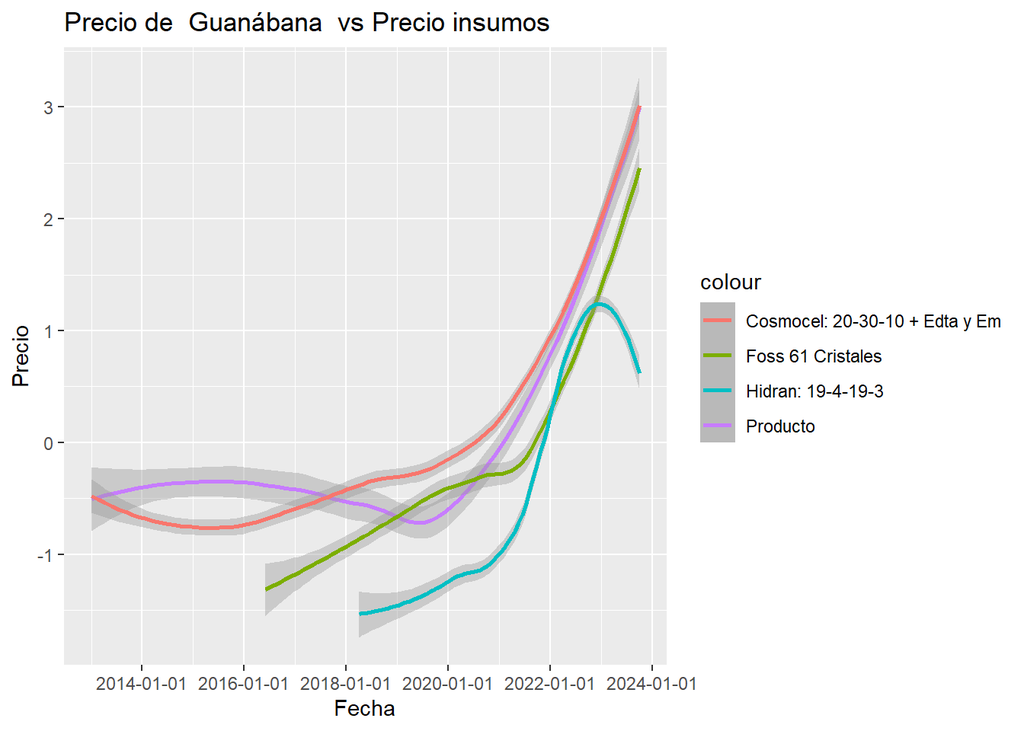

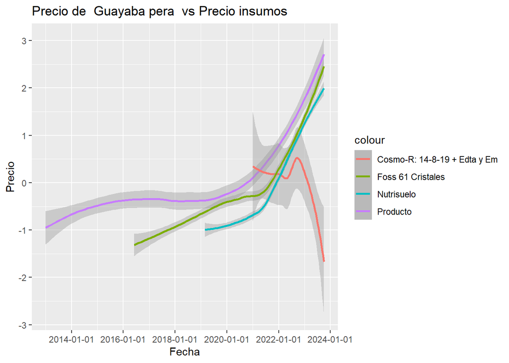

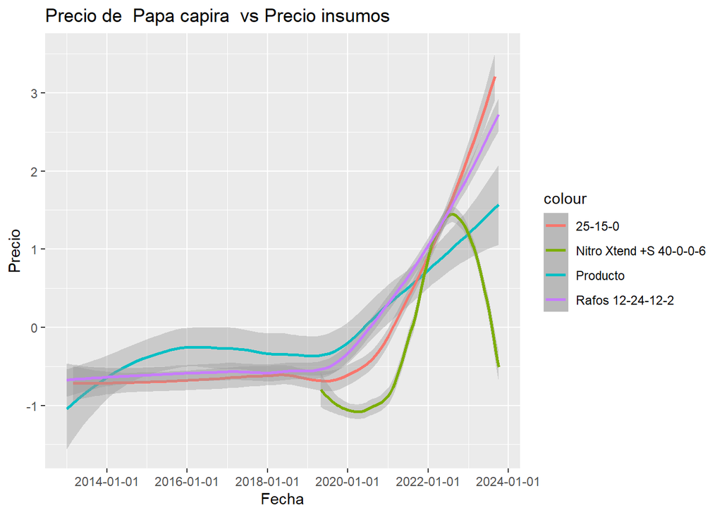

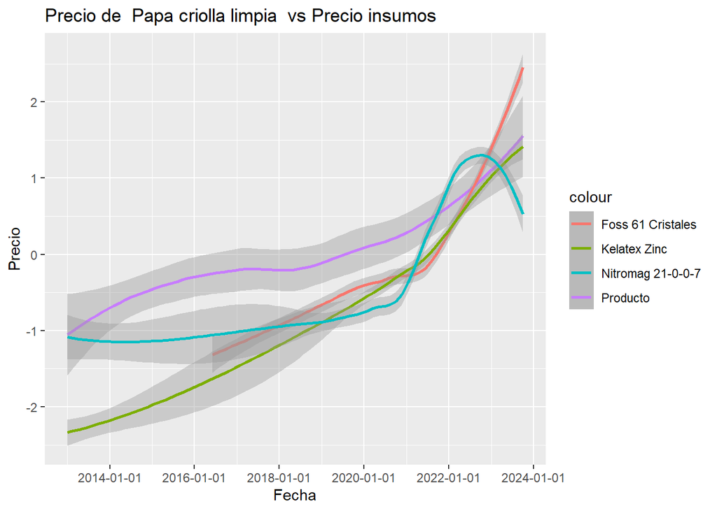

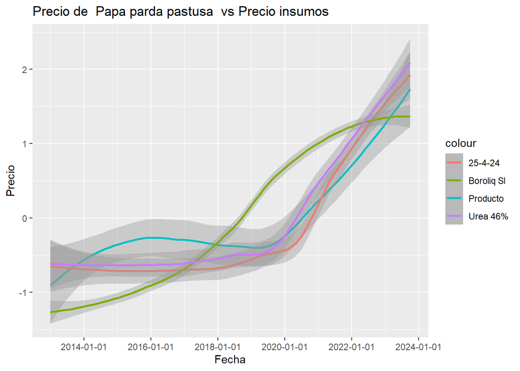

```r
# Hacer unas grafiquitas que sea en un mismo plot el precio del producto y el de los 3-5 insumos en el tiempo
promedios_regional <- d %>%
  group_by(Fecha, Producto) %>%
  summarize(Promedio = mean(Precio))
promedios_regional$Fecha =format(promedios_regional$Fecha, "%Y-%m-%d")

promedios_regionales_n <- promedios_regional %>%
  group_by(Producto) %>%
  mutate(precio_normalizado = scale(Promedio))


for( i in unique(top_correlations$Producto)){
  producto <- promedios_regionales_n %>%
    filter(Producto == i)

  nombres_insumos_producto <- filter(top_correlations, Producto == i)$Insumo

  insumos_producto  <- insumos_andino %>%
    filter(Insumo %in% nombres_insumos_producto) %>%
    group_by(Fecha, Insumo) %>%
    summarize(Promedio = mean(`Precio promedio`))

  insumos_producto <- insumos_producto %>%
    group_by(Insumo) %>%
    mutate(precio_normalizado = scale(Promedio))

  producto$Fecha <- as.Date(producto$Fecha)
  insumos_producto$Fecha <- as.Date(insumos_producto$Fecha)
  h <- ggplot() +
    geom_smooth(data = producto, aes(x = Fecha, y = precio_normalizado, color = "Producto")) +
    geom_smooth(data = insumos_producto, aes(x = Fecha, y = precio_normalizado, group = Insumo, color = Insumo))+
    labs(title = paste("Precio de ",i, " vs Precio insumos"),
         y = "Precio") +
    scale_x_date(date_labels = "%Y-%m-%d")

  print(h)
}
```

## 5.4 ¿Qué encontramos en internet sobre estos productos?

Al investigar sobre los cultivo que vimos anteriormente en la región andina de Colombia, encontramos lo siguiente:

### 5.4.1 Fresa

- Las fresas se cultivan durante todo el año en Colombia.
- El principal departamento productor de fresas es Cundinamarca, que representa el 51% del área de cultivo nacional en 2020. Le siguen Boyacá, Cauca y Norte de Santander.
- Su producción se vió afectada después de la pandemia.

### 5.4.2 Guanábana

- La guanábana representa el 1.6% de la producción total de frutas en el país.
- A pesar de su potencial, el cultivo de guanábana está limitado debido a su alto riesgo, requisitos climáticos específicos y rendimiento tardío.
- Aproximadamente el 25% de la producción de guanábana se exporta, principalmente a Estados Unidos.
- El cultivo de guanábana requiere un microclima único, lo que lo hace susceptible a riesgos climáticos.

### 5.4.3 Guayaba

- La industria de la guayaba ha prosperado en regiones específicas de Colombia, incluyendo Santander (municipios de Barbosa y Vélez) y Moniquirá en Boyacá.
- Los desafíos en el cultivo de guayaba incluyen la sincronización de las cosechas debido a la distribución de la precipitación, lo que resulta en un exceso de oferta y fluctuaciones de precios.
- La sostenibilidad económica en el cultivo de guayaba se logra mediante estrategias como la modificación del pico de cosecha principal mediante riego, ajuste en el momento de la poda y la agroindustrialización para la producción de productos a base de guayaba.

### 5.4.4 Papa

- A nivel mundial, la papa es el tercer producto alimenticio más importante después del arroz y el trigo. En Colombia, las papas contribuyen significativamente al PIB agropecuario (3.3%).
- Los costos de producción varían según el departamento debido a dinámicas regionales.
- El 90% del área de cultivo de papa en Colombia se concentra en cuatro departamentos: Cundinamarca, Boyacá, Nariño y Antioquia.
- La cadena de suministro de papas genera aproximadamente 264,000 empleos totales en Colombia, con una parte sustancial siendo empleos indirectos.
- Las variaciones en el cultivo de papa están influenciadas por factores como el área sembrada y las condiciones climáticas. Las papas son sensibles a las fluctuaciones de temperatura e inundaciones.

# 6 Discusión

Comenzando con los productos que presentaron la menor desviación estándar tenemos a la fresa, la guanábanay la guayaba. Observamos que estos son productos que siguen la tendencia de la inflación con una correlación de 80% aproximadamente.

En cuanto a su correlación con los fertilizantes observamos que aunque algunas correlaciones parecian seguir la misma tendencia de los precios del producto, otras no daban ese indicio. Por lo que consideramos que este punto fue no concluyente. Creemos que con el conocimiento previo de los fertilizantes que se usan en cada producto este punto podría ofrecer resultados más significativos.

A partir de esto creemos que estos tres productos demuestran un comportamiento relativamente estable en los precios en mercados mayoristas en la región andina, por lo que pueden ser potencialmente buenos productos para una siembra estable y sin muchos riesgos, como también lo corroboramos con la búsqueda en internet.

Por otro lado los productos de mayor desviación estándar a lo largo del tiempo resultaron ser diferentes variedades de papa.

Presentaron una correlación de alrededor del 60% con la tasa de inflación nacional, un 20% menos que la de los productos con menor variabilidad. Puede que esto se deba a que hay otros factores que también afectan los precios de estos productos de forma bastante significativa.

En cuento a la correlación con los fertilizantes, también se presentaron correlaciones altas y positivas como era de esperarse, pero sin el conocimiento previo de cuáles fertilizantes se usan para estos cultivos en la región, consideramos que no podemos extraer mucha información de estos valores.

En síntesis, en estos variedades de papa observamos un comportamiento más inestable a lo largo del año, como también lo indican fuentes externas es un producto muy susceptible a cambios en el clima, lo que podría explicar por quá presentan la mayor variabilidad. Es por esto que, aunque es uno de los cultivos más importantes de Colombia creemos que también es uno que potencialmente tiene más riesgo de perdida para el agricultor.

Otro punto es el comportamiento periodico de los datos, en lo que observamos tanto para los productos con menor y mayor variabilidad, creemos que no tenemos pruebas concluyentes para saber si el periodicidad es una característica propia de uno de otro, ya que ambos grupos presentaban ciclos anuales para algunos productos mientras que para otros no.

# 7 Conclusiones

- Estudiar la variación de los precios requiere de un enfoque integral, son muchos los factores que influyen en el precio de estos, desde los precios de los insumos, hasta las decisiones políticas. En este trabajo alcanzamos a abordar algunos, sin embargo, pudimos ver que eventos como la pandemia COVID19 genera unos cambios bruscos en el comportamiento.
- Aunque encontramos ciertas tendencias y correlaciones muy interesantes, el verdadero valor de estos datos y gráfico cobra sentido cuando son analizados bajo un ojo experto. Además existen relaciones no lineales que no pudimos representar en este trabajo, por lo que nuestros hallazgos podrían representar factores que influyen en los precios de los productos, más no son verdades absolutas.
- La recolección de estos tipos de datos es de gran importancia para el país, estos permiten, además de la estimación de medidas como la inflación, la toma de decisiones basadas en datos reales, actuales y significativos.
- Además de la importancia de la recolección de los datos, es también importante tener en cuenta su carácter de interés público, celebramos el poder acceder a estos. Sin embargo, las tecnologías usadas para su distribución dificultan los análisis, se debe procurar el uso de formatos abiertos y estructuras la información de una manera más adecuada.

# 8 Referencias

1. Razon Publica. “Los problemas del sector agrícola colombiano.” Visitado 2023-12-6. https://razonpublica.com/los-problemas-del-sector-agricola-colombiano/.
2. Semana. “Qué debe tener en cuenta el sector agrícola en 2023: aquí le contamos.” Semana Economía, 2022. https://www.semana.com/economia/macroeconomia/articulo/que-debe-tener-en-cuenta-el-sector-agricola-en-2023-aqui-le-contamos/202206/.
3. Portafolio. “Sector agro en Colombia: así está la situación de la industria en el país.” Revista Portafolio. Visitado 2023-12-6. https://www.portafolio.co/revista-portafolio/sector-agro-en-colombia-asi-esta-la-situacion-de-la-industria-en-el-pais-577013.
4. Ministerio de Agricultura y Desarrollo Rural. “Cifras Sectoriales.” 2021. https://sioc.minagricultura.gov.co/Fresa/Documentos/2021-03-31%20Cifras%20Sectoriales.pdf.
5. Agronegocios. “Guanábana, un cultivo al que muy pocos se le miden.” Visitado 2023-12-6.. https://www.agronegocios.co/agricultura/guanabana-un-cultivo-al-que-muy-pocos-se-le-miden-2621218.
6. Innovatione. “Guanábana.” Visitado 2023-12-6. https://innovatione.eu/2023/03/01/guanabana/#:~:text=Los%20principales%20departamentos%20productores%20de,mayor%20cabida%20en%20el%20extranjero.
7. Redalyc. “Estado actual de la investigación para el cultivo de guayaba en Colombia” Agronomía Mesoamericana, 2020 https://www.redalyc.org/journal/437/43764233031/html/#:~:text=Se%20estima%20que%20la%20producci%C3%B3n,et%20al.%2C%202017.
8. Ministerio de Agricultura y Desarrollo Rural. “Cifras Sectoriales.” 2020. https://sioc.minagricultura.gov.co/Guayaba/Documentos/2020-03-31%20Cifras%20Sectoriales.pdf.